# Tutorial

Hadrien Leclerc

2020-08-09

# Introduction

The insee package gathers tools to easily download data and metadata from [insee BDM database](https://www.insee.fr/en/information/2512785).

It uses SDMX queries under the hood. Have a look at the detailed [SDMX webservice page](https://www.insee.fr/en/information/2868055).

The first version of the package was published on CRAN 2020-07-29.

## Proxy issues

**Requirement for INSEE employees**

In order for someone working behind a proxy server to be able to use insee, it is necessary to modify system variables as follow.

```r
Sys.setenv(http_proxy = "my_proxy_server")
Sys.setenv(https_proxy = "my_proxy_server")
```

## Installation

You can easily install insee with the following code :

```r
install.packages("insee")
```

## Loading

You can easily load insee with the following code :

```r
library(insee)
```

This vignette uses the tidyverse package to exemplify the insee package functionalities with hands-on examples.

```r
library(tidyverse)
```

# Functionalities

This section will give you an overview of what you can do with insee.

Series have two identifiers the SDMX identifier and the so called idbank. Both can be used to download data.

## Datasets List

[INSEE BDM database](https://www.insee.fr/en/information/2512785) offers more than 200 Datasets. The `get_dataset_list()` function returns the datasets catalogue :

```r
insee_dataset <- get_dataset_list()
```

```
## 1/1 - Data download :
##
##
## Data cached : C:\Users\XLAPDO\AppData\Local\Temp\RtmpGK54Br/6bce20f8021f2b83467819f1e4f74d9f.rds
```

| id | Name.en | Name.fr | url | n_series |
| --- | --- | --- | --- | --- |
| BALANCE-PAIEMENTS | Balance of payments | Balance des paiements | https://www.insee.fr/fr/statistiques/series/103212755 | 197 |
| CHOMAGE-TRIM-NATIONAL | Unemployment, unemployment rate and halo by sex and age (ILO) | Chômage, taux de chômage par sexe et âge (sens BIT) | https://www.insee.fr/fr/statistiques/series/103167923 | 166 |
| CLIMAT-AFFAIRES | Business climate composite indicators | Indicateurs synthétiques du climat des affaires | https://www.insee.fr/fr/statistiques/series/103047029 | 3 |
| CNA-2010-CONSO-MEN | Households’ consumption | Consommation des ménages | https://www.insee.fr/fr/statistiques/series/102331845 | 2247 |
| CNA-2010-CONSO-SI | Final consumption expenditure by institutional sectors | Dépenses de consommation finale par secteur institutionnel | https://www.insee.fr/fr/statistiques/series/102809534 | 1391 |
| CNA-2010-CPEB | Production and operating accounts by branch | Comptes de production et d’exploitation par branche | https://www.insee.fr/fr/statistiques/series/102852781 | 2739 |
| CNA-2010-CSI | Institutional sectors accounts | Comptes des secteurs institutionnels | https://www.insee.fr/fr/statistiques/series/102321506 | 1173 |
| CNA-2010-DEP-APU | General government expenditure | Dépenses des administrations publiques | https://www.insee.fr/fr/statistiques/series/102334196 | 4400 |
| CNA-2010-DETTE-APU | Maastricht general government debt and public deficit | Dette et déficit des administrations publiques au sens de Maastricht | https://www.insee.fr/fr/statistiques/series/103212800 | 72 |
| CNA-2010-EMPLOI | Domestic employment, hours worked and hourly productivity | Emploi intérieur, durée effective travaillée et productivité horaire | https://www.insee.fr/fr/statistiques/series/102800357 | 702 |

## Series Key List

[INSEE BDM database](https://www.insee.fr/en/information/2512785) currently offers more than 140 000 Series. The `get_idbank_list` function returns the series catalogue.

```r
idbank_list = get_idbank_list()
```

| nomflow | idbank | cleFlow |
| --- | --- | --- |
| BALANCE-PAIEMENTS | 001694056 | M.BALANCE_DES_PAIEMENTS.CREDITS.009.VALEUR_ABSOLUE.FE.EUROS.BRUT.SO |
| CHOMAGE-TRIM-NATIONAL | 001688549 | T.CTTXC.TAUX.FE.1.00-24.POURCENT.CVS |
| CLIMAT-AFFAIRES | 001565530 | M.CLIMAT_AFFAIRES.ALL_SECT.INDICE.FM.SO.BRUT |
| CNA-2010-CONSO-MEN | 001691912 | A.CNA_CONSO_MENAGES_FONCTION.PCH.P4.FON01.VALEUR_ABSOLUE..FR-D976.EUR2010.BRUT.2010 |
| CNA-2010-CONSO-SI | 001703713 | A.CNA_CONSO_SI.S13.PCH.P3.A10-JZ.VALEUR_ABSOLUE.FE.EUR2010.BRUT |
| CNA-2010-CPEB | 001710115 | A.CNA_CPEB.A10-RU.IPCH.P1.INDICE.FE.SO.BRUT |
| CNA-2010-CSI | 001719388 | A.CNA_COMPTES_SI_EA.S0.EA.D7S.SO.FR-D976.EUROS_COURANTS.BRUT |
| CNA-2010-DEP-APU | 001730327 | A.CNA_DEP_APU.S1313.D1.VALEUR_ABSOLUE.FONTOTAL.FR-D976.EUROS_COURANTS.BRUT.2010 |
| CNA-2010-DETTE-APU | 001710846 | A.CNA_FINANCES_DETTE.S13.VAL.VALEUR_ABSOLUE.FE.EUROS_COURANTS.BRUT |
| CNA-2010-EMPLOI | 001693569 | A.CNA_EMPLOI_INTERIEUR.A10-RU.S10.VALEUR_ABSOLUE.E10.FE.NOMBRE_ACTIFS_OCCUPES_PP.BRUT |

## Find a series key

The best way to download data is to find the right series key (idbank), but how ? Indeed, in some cases it is not easy to understand what are the differences among series, especially for non-French speakers. To make the search easier, the insee package provides the function `get_insee_title` to get the title related to an idbank, either in English or in French. It is not advised to use the `get_insee_title` function on the whole idbank dataset, as each SDMX query has 400-idbank limit. Then, `get_insee_title` function splits the input into several lists of 400 idbanks each and is consequently quite slow. Thus, the user should filter the idbank dataset before using the `get_insee_title` function to avoid as much as possible this bottleneck as the following example shows.

```r
idbank_list = get_idbank_list()

idbank_list_selected =
  idbank_list %>%
  filter(nomflow == "IPI-2015") %>% #industrial production index dataset
  filter(dim1 == "M") %>% #monthly
  filter(dim5 == "INDICE") %>% #index
  filter(dim8 == "CVS-CJO") %>% #Working day and seasonally adjusted SA-WDA
  #automotive industry and overall industrial production
  filter(str_detect(dim4,"^29$|A10-BE")) %>%
  mutate(title = get_insee_title(idbank))

idbank_list_selected
```

## Download data

### Download using idbank

The `get_insee_idbank` function should handle up to 400 idbanks but not more. It is then advised to narrow down the idbanks list used as argument of the function.

```r
library(tidyverse)

# the user can make a manual list of idbanks to get the data
# example 1

data = get_insee_idbank("001558315", "010540726")

# using a list of idbanks extracted from the insee idbank dataset
# example 2 : household's confidence survey

idbank_dataset = get_idbank_list()

df_idbank = idbank_dataset %>%
  filter(nomflow == "ENQ-CONJ-MENAGES") %>%  #monthly households' confidence survey
  mutate(title = get_insee_title(idbank)) %>%
  separate(title, sep = " - ", into = paste0("title", 1:4),
           fill = "right", remove = FALSE) %>%
  filter(dim7 == "CVS") #seasonally adjusted

# dim2: IND_SYNT_CONF - Summary indicator of households' confidence

list_idbank = df_idbank %>% pull(idbank)

data = get_insee_idbank(list_idbank)
```

### Download using dataset name

For some datasets as IPC-2015 (inflation), the filter is necessary.

```r
insee_dataset <- get_dataset_list()

# example 1 : full dataset
data = get_insee_dataset("CLIMAT-AFFAIRES")

# example 2 : filtered dataset
# the user can filter the data
data = get_insee_dataset("IPC-2015", filter = "M+A.........CVS.", startPeriod = "2015-03")

# in the filter, the + is used to select several values in one dimension, like an "and" statement
# the void means "all" values available

# example 3 : only one series
# by filtering with the full SDMX series key, the user will get only one series
data =
  get_insee_dataset("CNA-2014-CPEB",
                    filter = "A.CNA_CPEB.A38-CB.VAL.D39.VALEUR_ABSOLUE.FE.EUROS_COURANTS.BRUT",
                    lastNObservations = 10)
```

# Useful examples

## GDP growth rate

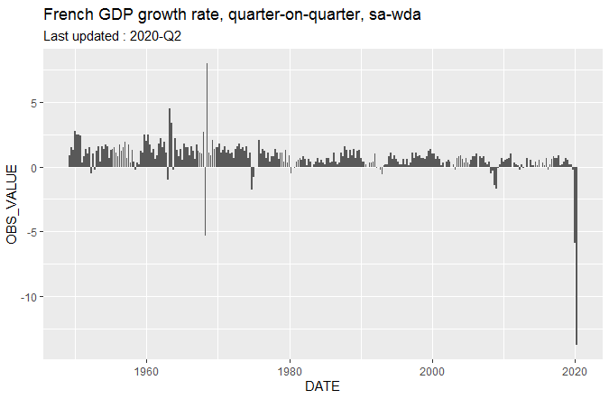

```r
library(tidyverse)

idbank_list = get_idbank_list()

df_idbank_list_selected =
  idbank_list %>%
  filter(nomflow == "CNT-2014-PIB-EQB-RF") %>% # Gross domestic product balance
  filter(dim1 == "T") %>% #quarter
  filter(dim4 == "PIB") %>% #GDP
  filter(dim6 == "TAUX") %>% #rate
  filter(dim10 == "CVS-CJO") #SA-WDA, seasonally adjusted, working day adjusted

idbank = df_idbank_list_selected %>% pull(idbank)

data = get_insee_idbank(idbank)

#plot
ggplot(data, aes(x = DATE, y = OBS_VALUE)) +
  geom_col() +
  ggtitle("French GDP growth rate, quarter-on-quarter, sa-wda") +
  labs(subtitle = sprintf("Last updated : %s", data$TIME_PERIOD[1]))
```

## Inflation

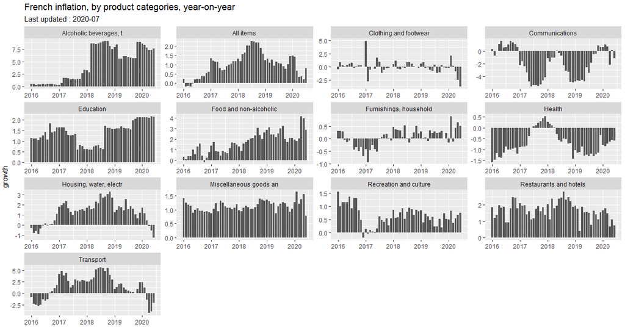

```r
library(tidyverse)
library(lubridate)

idbank_list = get_idbank_list()

df_idbank_list_selected =
  idbank_list %>%
  filter(nomflow == "IPC-2015") %>% #Inflation dataset
  filter(dim1 == "M") %>% # monthly
  filter(str_detect(dim4, "^[0-9]{2}$")) %>% # coicop aggregation level
  filter(dim6 == "INDICE") %>% # index
  filter(dim7 == "ENSEMBLE") %>% # all kinds of household
  filter(dim8 == "FE") %>% # all France including overseas departements
  mutate(title = get_insee_title(idbank))

list_idbank = df_idbank_list_selected %>% pull(idbank)

data = get_insee_idbank(list_idbank, startPeriod = "2015-01")

n_sep = str_count(data$TITLE_FR[1], " - ") + 1

data_plot = data %>%
  separate(TITLE_EN, into = paste0("title", 1:n_sep),
           sep = " - ", remove = FALSE, fill = "right") %>%
  mutate(title6 = case_when(is.na(title6) ~ title5,
                            TRUE ~ as.character(title6))) %>%
  mutate(title6 = substr(title6, 1 , 22)) %>%
  mutate(month = month(DATE)) %>%
  arrange(DATE) %>%
  group_by(title6, month) %>%
  mutate(growth = 100 * (OBS_VALUE / dplyr::lag(OBS_VALUE) - 1))

ggplot(data_plot, aes(x = DATE, y = growth)) +
  geom_col() +
  facet_wrap(~title6, scales = "free") +
  ggtitle("French inflation, by product categories, year-on-year") +
  labs(subtitle = sprintf("Last updated : %s", data_plot$TIME_PERIOD[nrow(data_plot)]))
```

## Unemployment rate

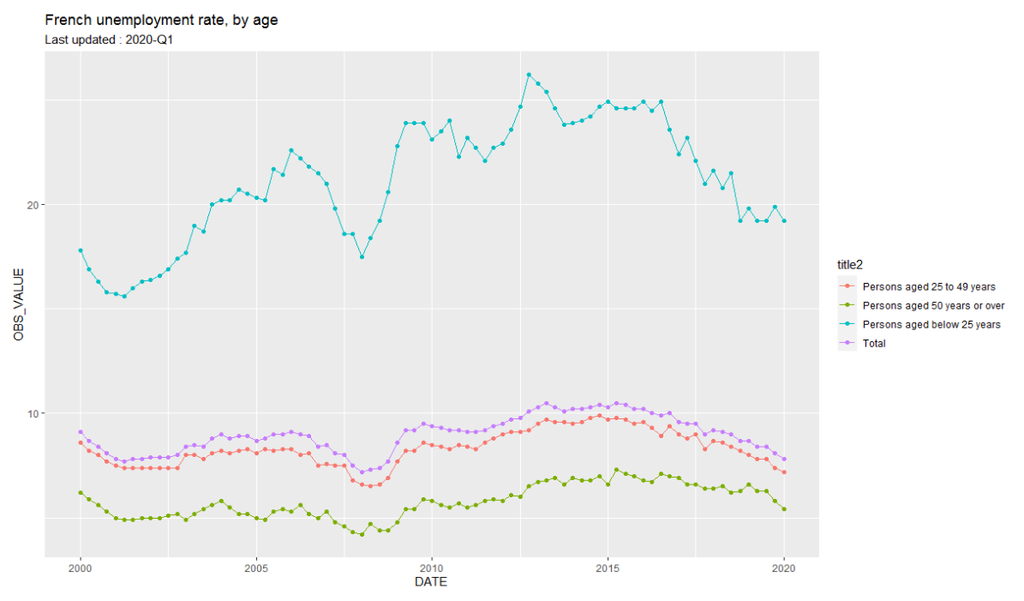

```r
library(tidyverse)

dataset_list = get_dataset_list()

idbank_list = get_idbank_list()

df_idbank_list_selected =
  idbank_list %>%
  filter(nomflow == "CHOMAGE-TRIM-NATIONAL") %>% #Unemployment dataset
  mutate(title = get_insee_title(idbank)) %>%
  filter(dim2 == "CTTXC") %>% #unemployment rate based on ILO standards
  filter(dim4 == "FE") %>%  # all France including overseas departements
  filter(dim5 == 0) # men and women

list_idbank = df_idbank_list_selected %>% pull(idbank)

data = get_insee_idbank(list_idbank, startPeriod = "2000-01")

n_sep = str_count(data$TITLE_FR[1], " - ") + 1

data_plot = data %>%
  separate(TITLE_EN, into = paste0("title", 1:n_sep),
           sep = " - ", remove = FALSE, fill = "right")

ggplot(data_plot, aes(x = DATE, y = OBS_VALUE, colour = title2)) +
  geom_line() +
  geom_point() +
  ggtitle("French unemployment rate, by age") +
  labs(subtitle = sprintf("Last updated : %s", data_plot$TIME_PERIOD[1]))
```

## Population

### Population by age

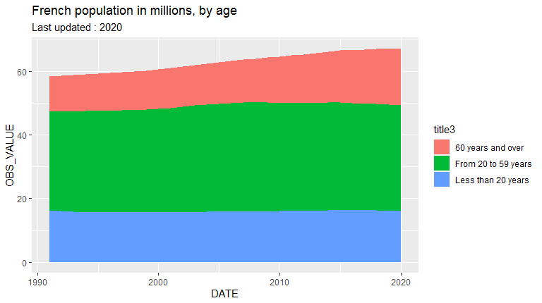

```r
library(tidyverse)

dataset_list = get_dataset_list()

idbank_list = get_idbank_list()

df_idbank_list_selected =
  idbank_list %>%
  filter(nomflow == "POPULATION-STRUCTURE") %>% #population dataset
  mutate(title = get_insee_title(idbank)) %>%
  filter(dim2 == "POPULATION_1ER_JANVIER") %>% #population at the beginning of the year
  filter(dim5 == "FE") %>%  # all France including overseas departements
  filter(dim6 == 0) %>%  # men and women
  filter(dim7 %in% c("00-19", "20-59", "60-")) #age ranges

list_idbank = df_idbank_list_selected %>% pull(idbank)

data = get_insee_idbank(list_idbank)

n_sep = str_count(data$TITLE_FR[1], " - ") + 1

data_plot = data %>%
  separate(TITLE_EN, into = paste0("title", 1:n_sep),
           sep = " - ", remove = FALSE, fill = "right") %>%
  mutate(OBS_VALUE = OBS_VALUE / 10^6)

ggplot(data_plot, aes(x = DATE, y = OBS_VALUE, fill = title3)) +
  geom_area() +
  ggtitle("French population in millions, by age") +
  labs(subtitle = sprintf("Last updated : %s", data_plot$TIME_PERIOD[1]))
```

### Population by departement

[figure not shown]

```r
library(insee)
library(tidyverse)

library(raster)
library(rgdal)
library(broom)
library(viridis)

idbank_list = get_idbank_list()

dataset_list = get_dataset_list()

list_idbank = idbank_list %>%
  filter(nomflow == "TCRED-ESTIMATIONS-POPULATION") %>%
  filter(dim6 == "00-") %>% #all ages
  filter(dim5 == 0) %>% #men and women
  filter(str_detect(dim4, "^D")) %>% #select only departements
  mutate(title = get_insee_title(idbank))

list_idbank_selected = list_idbank %>% pull(idbank)

# get population data by departement
pop = get_insee_idbank(list_idbank_selected)

#get departements' geographical limits
FranceMap <- raster::getData(name = "GADM", country = "FRA", level = 2)

# extract the population by departement in 2020
pop_plot = pop %>%
  group_by(TITLE_EN) %>%
  filter(DATE == "2020-01-01") %>%
  mutate(dptm = gsub("D", "", REF_AREA)) %>%
  filter(dptm %in% FranceMap@data$CC_2) %>%
  mutate(dptm = factor(dptm, levels = FranceMap@data$CC_2)) %>%
  arrange(dptm) %>%
  mutate(id = dptm)

vec_pop = pop_plot %>% pull(OBS_VALUE)

# add population data to the departement object map
FranceMap@data$pop = vec_pop

# extract the departements' limits from the spatial object
FranceMap_tidy <- broom::tidy(FranceMap)

# mapping table
dptm_df = data.frame(dptm = FranceMap@data$CC_2,
                     dptm_name = FranceMap@data$NAME_2,
                     pop = FranceMap@data$pop,
                     id = rownames(FranceMap@data))

# add population data to departement dataframe
FranceMap_tidy_final =
  FranceMap_tidy %>%
  left_join(dptm_df, by = "id") %>%
  dplyr::select(long, lat, pop, group, id)

ggplot() +
  geom_polygon(data = FranceMap_tidy_final,
               aes(fill = pop, x = long, y = lat, group = group) ,
               size = 0, alpha = 0.9) +
  coord_map() +
  theme_void() +
  scale_fill_viridis() +
  ggtitle("Distribution of the population within French territory in 2020")
```

# Support

# Disclaimer

This package is in no way officially related to or endorsed by INSEE.